# Risk Factor Analysis

## Outcome Variable

**Outcome Variable:** wast_rec90d

## Predictor Variables

**Intervention Variable:** enwast

**Adjustment Set:**

unadjusted

## Stratifying Variables

The analysis was stratified on these variable(s):

- agecat
- studyid
- country

## Data Summary

| agecat | studyid | country | enwast | wast_rec90d | n_cell | n |
| --- | --- | --- | --- | --- | --- | --- |
| 0-24 months | ki0047075b-MAL-ED | BANGLADESH | 0 | 0 | 29 | 113 |
| 0-24 months | ki0047075b-MAL-ED | BANGLADESH | 0 | 1 | 25 | 113 |
| 0-24 months | ki0047075b-MAL-ED | BANGLADESH | 1 | 0 | 11 | 113 |
| 0-24 months | ki0047075b-MAL-ED | BANGLADESH | 1 | 1 | 48 | 113 |
| 0-24 months | ki0047075b-MAL-ED | BRAZIL | 0 | 0 | 4 | 22 |
| 0-24 months | ki0047075b-MAL-ED | BRAZIL | 0 | 1 | 11 | 22 |
| 0-24 months | ki0047075b-MAL-ED | BRAZIL | 1 | 0 | 1 | 22 |
| 0-24 months | ki0047075b-MAL-ED | BRAZIL | 1 | 1 | 6 | 22 |
| 0-24 months | ki0047075b-MAL-ED | INDIA | 0 | 0 | 40 | 173 |
| 0-24 months | ki0047075b-MAL-ED | INDIA | 0 | 1 | 67 | 173 |
| 0-24 months | ki0047075b-MAL-ED | INDIA | 1 | 0 | 29 | 173 |
| 0-24 months | ki0047075b-MAL-ED | INDIA | 1 | 1 | 37 | 173 |
| 0-24 months | ki0047075b-MAL-ED | NEPAL | 0 | 0 | 10 | 90 |
| 0-24 months | ki0047075b-MAL-ED | NEPAL | 0 | 1 | 44 | 90 |
| 0-24 months | ki0047075b-MAL-ED | NEPAL | 1 | 0 | 9 | 90 |
| 0-24 months | ki0047075b-MAL-ED | NEPAL | 1 | 1 | 27 | 90 |
| 0-24 months | ki0047075b-MAL-ED | PERU | 0 | 0 | 6 | 34 |
| 0-24 months | ki0047075b-MAL-ED | PERU | 0 | 1 | 22 | 34 |
| 0-24 months | ki0047075b-MAL-ED | PERU | 1 | 0 | 0 | 34 |
| 0-24 months | ki0047075b-MAL-ED | PERU | 1 | 1 | 6 | 34 |
| 0-24 months | ki0047075b-MAL-ED | SOUTH AFRICA | 0 | 0 | 11 | 83 |
| 0-24 months | ki0047075b-MAL-ED | SOUTH AFRICA | 0 | 1 | 47 | 83 |
| 0-24 months | ki0047075b-MAL-ED | SOUTH AFRICA | 1 | 0 | 6 | 83 |
| 0-24 months | ki0047075b-MAL-ED | SOUTH AFRICA | 1 | 1 | 19 | 83 |
| 0-24 months | ki0047075b-MAL-ED | TANZANIA, UNITED REPUBLIC OF | 0 | 0 | 8 | 44 |
| 0-24 months | ki0047075b-MAL-ED | TANZANIA, UNITED REPUBLIC OF | 0 | 1 | 32 | 44 |
| 0-24 months | ki0047075b-MAL-ED | TANZANIA, UNITED REPUBLIC OF | 1 | 0 | 0 | 44 |
| 0-24 months | ki0047075b-MAL-ED | TANZANIA, UNITED REPUBLIC OF | 1 | 1 | 4 | 44 |
| 0-24 months | ki1000108-CMC-V-BCS-2002 | INDIA | 0 | 0 | 75 | 321 |
| 0-24 months | ki1000108-CMC-V-BCS-2002 | INDIA | 0 | 1 | 115 | 321 |

[output cut: 374 more lines]

The following strata were considered:

- agecat: 0-24 months, studyid: ki0047075b-MAL-ED, country: BANGLADESH
- agecat: 0-24 months, studyid: ki0047075b-MAL-ED, country: BRAZIL
- agecat: 0-24 months, studyid: ki0047075b-MAL-ED, country: INDIA
- agecat: 0-24 months, studyid: ki0047075b-MAL-ED, country: NEPAL
- agecat: 0-24 months, studyid: ki0047075b-MAL-ED, country: PERU
- agecat: 0-24 months, studyid: ki0047075b-MAL-ED, country: SOUTH AFRICA
- agecat: 0-24 months, studyid: ki0047075b-MAL-ED, country: TANZANIA, UNITED REPUBLIC OF
- agecat: 0-24 months, studyid: ki1000108-CMC-V-BCS-2002, country: INDIA
- agecat: 0-24 months, studyid: ki1000108-IRC, country: INDIA
- agecat: 0-24 months, studyid: ki1000109-EE, country: PAKISTAN
- agecat: 0-24 months, studyid: ki1000109-ResPak, country: PAKISTAN
- agecat: 0-24 months, studyid: ki1000304b-SAS-CompFeed, country: INDIA
- agecat: 0-24 months, studyid: ki1000304b-SAS-FoodSuppl, country: INDIA
- agecat: 0-24 months, studyid: ki1017093-NIH-Birth, country: BANGLADESH
- agecat: 0-24 months, studyid: ki1017093b-PROVIDE, country: BANGLADESH
- agecat: 0-24 months, studyid: ki1017093c-NIH-Crypto, country: BANGLADESH
- agecat: 0-24 months, studyid: ki1066203-TanzaniaChild2, country: TANZANIA, UNITED REPUBLIC OF
- agecat: 0-24 months, studyid: ki1101329-Keneba, country: GAMBIA
- agecat: 0-24 months, studyid: ki1112895-Guatemala BSC, country: GUATEMALA
- agecat: 0-24 months, studyid: ki1112895-iLiNS-Zinc, country: BURKINA FASO
- agecat: 0-24 months, studyid: ki1113344-GMS-Nepal, country: NEPAL
- agecat: 0-24 months, studyid: ki1114097-CMIN, country: BANGLADESH
- agecat: 0-24 months, studyid: ki1114097-CMIN, country: BRAZIL
- agecat: 0-24 months, studyid: ki1114097-CMIN, country: GUINEA-BISSAU
- agecat: 0-24 months, studyid: ki1114097-CMIN, country: PERU
- agecat: 0-24 months, studyid: ki1114097-CONTENT, country: PERU
- agecat: 0-24 months, studyid: ki1119695-PROBIT, country: BELARUS
- agecat: 0-24 months, studyid: ki1126311-ZVITAMBO, country: ZIMBABWE
- agecat: 0-24 months, studyid: ki1135781-COHORTS, country: GUATEMALA
- agecat: 0-24 months, studyid: ki1135781-COHORTS, country: INDIA
- agecat: 0-24 months, studyid: ki1135781-COHORTS, country: PHILIPPINES
- agecat: 0-24 months, studyid: ki1148112-LCNI-5, country: MALAWI
- agecat: 0-24 months, studyid: kiGH5241-JiVitA-3, country: BANGLADESH
- agecat: 0-24 months, studyid: kiGH5241-JiVitA-4, country: BANGLADESH
- agecat: 0-6 months, studyid: ki0047075b-MAL-ED, country: BANGLADESH
- agecat: 0-6 months, studyid: ki0047075b-MAL-ED, country: BRAZIL
- agecat: 0-6 months, studyid: ki0047075b-MAL-ED, country: INDIA
- agecat: 0-6 months, studyid: ki0047075b-MAL-ED, country: NEPAL
- agecat: 0-6 months, studyid: ki0047075b-MAL-ED, country: PERU
- agecat: 0-6 months, studyid: ki0047075b-MAL-ED, country: SOUTH AFRICA
- agecat: 0-6 months, studyid: ki0047075b-MAL-ED, country: TANZANIA, UNITED REPUBLIC OF
- agecat: 0-6 months, studyid: ki1000108-CMC-V-BCS-2002, country: INDIA
- agecat: 0-6 months, studyid: ki1000108-IRC, country: INDIA
- agecat: 0-6 months, studyid: ki1000109-EE, country: PAKISTAN
- agecat: 0-6 months, studyid: ki1000109-ResPak, country: PAKISTAN
- agecat: 0-6 months, studyid: ki1000304b-SAS-CompFeed, country: INDIA
- agecat: 0-6 months, studyid: ki1000304b-SAS-FoodSuppl, country: INDIA
- agecat: 0-6 months, studyid: ki1017093-NIH-Birth, country: BANGLADESH
- agecat: 0-6 months, studyid: ki1017093b-PROVIDE, country: BANGLADESH
- agecat: 0-6 months, studyid: ki1017093c-NIH-Crypto, country: BANGLADESH
- agecat: 0-6 months, studyid: ki1066203-TanzaniaChild2, country: TANZANIA, UNITED REPUBLIC OF
- agecat: 0-6 months, studyid: ki1101329-Keneba, country: GAMBIA
- agecat: 0-6 months, studyid: ki1112895-Guatemala BSC, country: GUATEMALA
- agecat: 0-6 months, studyid: ki1113344-GMS-Nepal, country: NEPAL
- agecat: 0-6 months, studyid: ki1114097-CMIN, country: BANGLADESH
- agecat: 0-6 months, studyid: ki1114097-CMIN, country: BRAZIL
- agecat: 0-6 months, studyid: ki1114097-CMIN, country: GUINEA-BISSAU
- agecat: 0-6 months, studyid: ki1114097-CMIN, country: PERU
- agecat: 0-6 months, studyid: ki1114097-CONTENT, country: PERU
- agecat: 0-6 months, studyid: ki1119695-PROBIT, country: BELARUS
- agecat: 0-6 months, studyid: ki1126311-ZVITAMBO, country: ZIMBABWE
- agecat: 0-6 months, studyid: ki1135781-COHORTS, country: GUATEMALA
- agecat: 0-6 months, studyid: ki1135781-COHORTS, country: INDIA
- agecat: 0-6 months, studyid: ki1135781-COHORTS, country: PHILIPPINES
- agecat: 0-6 months, studyid: ki1148112-LCNI-5, country: MALAWI
- agecat: 0-6 months, studyid: kiGH5241-JiVitA-3, country: BANGLADESH
- agecat: 0-6 months, studyid: kiGH5241-JiVitA-4, country: BANGLADESH
- agecat: 6-24 months, studyid: ki0047075b-MAL-ED, country: BANGLADESH
- agecat: 6-24 months, studyid: ki0047075b-MAL-ED, country: BRAZIL
- agecat: 6-24 months, studyid: ki0047075b-MAL-ED, country: INDIA
- agecat: 6-24 months, studyid: ki0047075b-MAL-ED, country: NEPAL
- agecat: 6-24 months, studyid: ki0047075b-MAL-ED, country: PERU
- agecat: 6-24 months, studyid: ki0047075b-MAL-ED, country: SOUTH AFRICA
- agecat: 6-24 months, studyid: ki0047075b-MAL-ED, country: TANZANIA, UNITED REPUBLIC OF
- agecat: 6-24 months, studyid: ki1000108-CMC-V-BCS-2002, country: INDIA
- agecat: 6-24 months, studyid: ki1000108-IRC, country: INDIA
- agecat: 6-24 months, studyid: ki1000109-EE, country: PAKISTAN
- agecat: 6-24 months, studyid: ki1000109-ResPak, country: PAKISTAN
- agecat: 6-24 months, studyid: ki1000304b-SAS-CompFeed, country: INDIA
- agecat: 6-24 months, studyid: ki1000304b-SAS-FoodSuppl, country: INDIA
- agecat: 6-24 months, studyid: ki1017093-NIH-Birth, country: BANGLADESH
- agecat: 6-24 months, studyid: ki1017093b-PROVIDE, country: BANGLADESH
- agecat: 6-24 months, studyid: ki1017093c-NIH-Crypto, country: BANGLADESH
- agecat: 6-24 months, studyid: ki1066203-TanzaniaChild2, country: TANZANIA, UNITED REPUBLIC OF
- agecat: 6-24 months, studyid: ki1101329-Keneba, country: GAMBIA
- agecat: 6-24 months, studyid: ki1112895-Guatemala BSC, country: GUATEMALA
- agecat: 6-24 months, studyid: ki1112895-iLiNS-Zinc, country: BURKINA FASO
- agecat: 6-24 months, studyid: ki1113344-GMS-Nepal, country: NEPAL
- agecat: 6-24 months, studyid: ki1114097-CMIN, country: BANGLADESH
- agecat: 6-24 months, studyid: ki1114097-CMIN, country: BRAZIL
- agecat: 6-24 months, studyid: ki1114097-CMIN, country: GUINEA-BISSAU
- agecat: 6-24 months, studyid: ki1114097-CMIN, country: PERU
- agecat: 6-24 months, studyid: ki1114097-CONTENT, country: PERU
- agecat: 6-24 months, studyid: ki1119695-PROBIT, country: BELARUS
- agecat: 6-24 months, studyid: ki1126311-ZVITAMBO, country: ZIMBABWE
- agecat: 6-24 months, studyid: ki1135781-COHORTS, country: GUATEMALA
- agecat: 6-24 months, studyid: ki1135781-COHORTS, country: INDIA
- agecat: 6-24 months, studyid: ki1135781-COHORTS, country: PHILIPPINES
- agecat: 6-24 months, studyid: ki1148112-LCNI-5, country: MALAWI
- agecat: 6-24 months, studyid: kiGH5241-JiVitA-3, country: BANGLADESH
- agecat: 6-24 months, studyid: kiGH5241-JiVitA-4, country: BANGLADESH

### Dropped Strata

Some strata were dropped due to rare outcomes:

- agecat: 0-24 months, studyid: ki0047075b-MAL-ED, country: BRAZIL
- agecat: 0-24 months, studyid: ki0047075b-MAL-ED, country: PERU
- agecat: 0-24 months, studyid: ki0047075b-MAL-ED, country: TANZANIA, UNITED REPUBLIC OF
- agecat: 0-24 months, studyid: ki1000304b-SAS-FoodSuppl, country: INDIA
- agecat: 0-24 months, studyid: ki1112895-Guatemala BSC, country: GUATEMALA
- agecat: 0-24 months, studyid: ki1114097-CMIN, country: BRAZIL
- agecat: 0-24 months, studyid: ki1114097-CONTENT, country: PERU
- agecat: 0-24 months, studyid: ki1135781-COHORTS, country: GUATEMALA
- agecat: 0-24 months, studyid: ki1135781-COHORTS, country: INDIA
- agecat: 0-24 months, studyid: ki1148112-LCNI-5, country: MALAWI
- agecat: 0-6 months, studyid: ki0047075b-MAL-ED, country: BANGLADESH
- agecat: 0-6 months, studyid: ki0047075b-MAL-ED, country: BRAZIL
- agecat: 0-6 months, studyid: ki0047075b-MAL-ED, country: NEPAL
- agecat: 0-6 months, studyid: ki0047075b-MAL-ED, country: PERU
- agecat: 0-6 months, studyid: ki0047075b-MAL-ED, country: SOUTH AFRICA
- agecat: 0-6 months, studyid: ki0047075b-MAL-ED, country: TANZANIA, UNITED REPUBLIC OF
- agecat: 0-6 months, studyid: ki1000304b-SAS-FoodSuppl, country: INDIA
- agecat: 0-6 months, studyid: ki1112895-Guatemala BSC, country: GUATEMALA
- agecat: 0-6 months, studyid: ki1114097-CMIN, country: BRAZIL
- agecat: 0-6 months, studyid: ki1114097-CMIN, country: PERU
- agecat: 0-6 months, studyid: ki1114097-CONTENT, country: PERU
- agecat: 0-6 months, studyid: ki1135781-COHORTS, country: GUATEMALA
- agecat: 0-6 months, studyid: ki1135781-COHORTS, country: INDIA
- agecat: 0-6 months, studyid: ki1148112-LCNI-5, country: MALAWI
- agecat: 6-24 months, studyid: ki0047075b-MAL-ED, country: BRAZIL
- agecat: 6-24 months, studyid: ki0047075b-MAL-ED, country: INDIA
- agecat: 6-24 months, studyid: ki0047075b-MAL-ED, country: NEPAL
- agecat: 6-24 months, studyid: ki0047075b-MAL-ED, country: PERU
- agecat: 6-24 months, studyid: ki0047075b-MAL-ED, country: SOUTH AFRICA
- agecat: 6-24 months, studyid: ki0047075b-MAL-ED, country: TANZANIA, UNITED REPUBLIC OF
- agecat: 6-24 months, studyid: ki1000304b-SAS-FoodSuppl, country: INDIA
- agecat: 6-24 months, studyid: ki1112895-Guatemala BSC, country: GUATEMALA
- agecat: 6-24 months, studyid: ki1114097-CMIN, country: BRAZIL
- agecat: 6-24 months, studyid: ki1114097-CMIN, country: GUINEA-BISSAU
- agecat: 6-24 months, studyid: ki1114097-CONTENT, country: PERU
- agecat: 6-24 months, studyid: ki1135781-COHORTS, country: GUATEMALA
- agecat: 6-24 months, studyid: ki1135781-COHORTS, country: INDIA
- agecat: 6-24 months, studyid: ki1148112-LCNI-5, country: MALAWI
- agecat: 6-24 months, studyid: kiGH5241-JiVitA-3, country: BANGLADESH

## Methods Detail

We’re interested in the causal parameters $E[Y_a]$ for all values of $a \in \mathcal{A}$. These parameters represent the mean outcome if, possibly contrary to fact, we intervened to set all units to have $A=a$. Under the randomization and positivity assumptions, these are identified by the statistical parameters $\psi_a=E_W[E_{Y|A,W}(Y|A=a,W)]$. In addition, we’re interested in the mean of $Y$, $E[Y]$ under no intervention (the observed mean). We will estimate these parameters by using SuperLearner to fit the relevant likelihood factors – $E_{Y|A,W}(Y|A=a,W)$ and $p(A=a|W)$, and then updating our likelihood fit using a joint TMLE.

For unadjusted analyses ($W=\{\}$), initial likelihoods were estimated using Lrnr_glm to estimate the simple $E(Y|A)$ and Lrnr_mean to estimate $p(A)$. For adjusted analyses, a small library containing Lrnr_glmnet, Lrnr_xgboost, and Lrnr_mean was used.

Having estimated these parameters, we will then use the delta method to estimate relative risks and attributable risks relative to a prespecified baseline level of $A$.

# Results Detail

## Results Plots

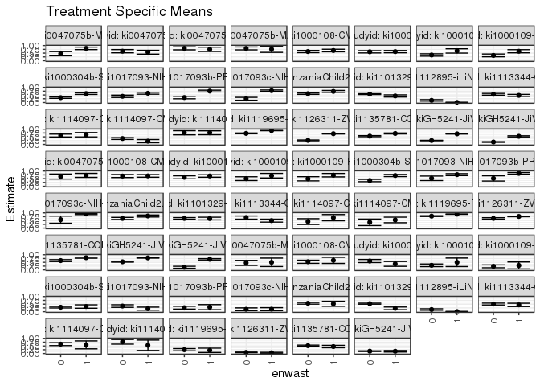

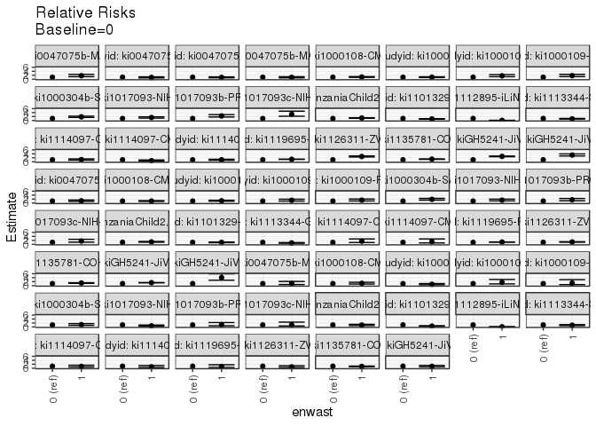

[figure not shown]

[figure not shown]

## Results Table

### Parameter: TSM

| agecat | studyid | country | intervention_level | baseline_level | estimate | ci_lower | ci_upper |
| --- | --- | --- | --- | --- | --- | --- | --- |
| 0-24 months | ki0047075b-MAL-ED | BANGLADESH | 0 | NA | 0.4629630 | 0.3229710 | 0.6029550 |
| 0-24 months | ki0047075b-MAL-ED | BANGLADESH | 1 | NA | 0.8135593 | 0.7326372 | 0.8944815 |
| 0-24 months | ki0047075b-MAL-ED | INDIA | 0 | NA | 0.6261682 | 0.5186038 | 0.7337327 |
| 0-24 months | ki0047075b-MAL-ED | INDIA | 1 | NA | 0.5606061 | 0.4359209 | 0.6852912 |
| 0-24 months | ki0047075b-MAL-ED | NEPAL | 0 | NA | 0.8148148 | 0.7154559 | 0.9141737 |
| 0-24 months | ki0047075b-MAL-ED | NEPAL | 1 | NA | 0.7500000 | 0.6093835 | 0.8906165 |
| 0-24 months | ki0047075b-MAL-ED | SOUTH AFRICA | 0 | NA | 0.8103448 | 0.7144543 | 0.9062354 |
| 0-24 months | ki0047075b-MAL-ED | SOUTH AFRICA | 1 | NA | 0.7600000 | 0.5500655 | 0.9699345 |
| 0-24 months | ki1000108-CMC-V-BCS-2002 | INDIA | 0 | NA | 0.6052632 | 0.5310568 | 0.6794695 |
| 0-24 months | ki1000108-CMC-V-BCS-2002 | INDIA | 1 | NA | 0.6717557 | 0.5859632 | 0.7575482 |
| 0-24 months | ki1000108-IRC | INDIA | 0 | NA | 0.5879397 | 0.5126115 | 0.6632679 |
| 0-24 months | ki1000108-IRC | INDIA | 1 | NA | 0.5988372 | 0.5233911 | 0.6742833 |
| 0-24 months | ki1000109-EE | PAKISTAN | 0 | NA | 0.3771429 | 0.2994224 | 0.4548634 |
| 0-24 months | ki1000109-EE | PAKISTAN | 1 | NA | 0.6444444 | 0.5032197 | 0.7856692 |
| 0-24 months | ki1000109-ResPak | PAKISTAN | 0 | NA | 0.3495935 | 0.2578351 | 0.4413519 |
| 0-24 months | ki1000109-ResPak | PAKISTAN | 1 | NA | 0.6231884 | 0.5187212 | 0.7276556 |
| 0-24 months | ki1000304b-SAS-CompFeed | INDIA | 0 | NA | 0.3220676 | 0.2764580 | 0.3676772 |
| 0-24 months | ki1000304b-SAS-CompFeed | INDIA | 1 | NA | 0.5922747 | 0.5361668 | 0.6483825 |
| 0-24 months | ki1017093-NIH-Birth | BANGLADESH | 0 | NA | 0.4117647 | 0.3351663 | 0.4883631 |
| 0-24 months | ki1017093-NIH-Birth | BANGLADESH | 1 | NA | 0.6125000 | 0.5488638 | 0.6761362 |
| 0-24 months | ki1017093b-PROVIDE | BANGLADESH | 0 | NA | 0.3306452 | 0.2494292 | 0.4118611 |
| 0-24 months | ki1017093b-PROVIDE | BANGLADESH | 1 | NA | 0.7569061 | 0.6980104 | 0.8158018 |
| 0-24 months | ki1017093c-NIH-Crypto | BANGLADESH | 0 | NA | 0.2469136 | 0.1512735 | 0.3425537 |
| 0-24 months | ki1017093c-NIH-Crypto | BANGLADESH | 1 | NA | 0.7837838 | 0.7389407 | 0.8286268 |
| 0-24 months | ki1066203-TanzaniaChild2 | TANZANIA, UNITED REPUBLIC OF | 0 | NA | 0.5858779 | 0.5404909 | 0.6312649 |
| 0-24 months | ki1066203-TanzaniaChild2 | TANZANIA, UNITED REPUBLIC OF | 1 | NA | 0.7351351 | 0.6725513 | 0.7977189 |
| 0-24 months | ki1101329-Keneba | GAMBIA | 0 | NA | 0.5560712 | 0.5267202 | 0.5854221 |
| 0-24 months | ki1101329-Keneba | GAMBIA | 1 | NA | 0.4354067 | 0.3632744 | 0.5075390 |
| 0-24 months | ki1112895-iLiNS-Zinc | BURKINA FASO | 0 | NA | 0.1435185 | 0.0941707 | 0.1928664 |
| 0-24 months | ki1112895-iLiNS-Zinc | BURKINA FASO | 1 | NA | 0.0082781 | 0.0043603 | 0.0121960 |

[output cut: 94 more lines]

### Parameter: E(Y)

| agecat | studyid | country | intervention_level | baseline_level | estimate | ci_lower | ci_upper |
| --- | --- | --- | --- | --- | --- | --- | --- |
| 0-24 months | ki0047075b-MAL-ED | BANGLADESH | NA | NA | 0.6460177 | 0.5560255 | 0.7360099 |
| 0-24 months | ki0047075b-MAL-ED | INDIA | NA | NA | 0.6011561 | 0.5195404 | 0.6827718 |
| 0-24 months | ki0047075b-MAL-ED | NEPAL | NA | NA | 0.7888889 | 0.7072560 | 0.8705218 |
| 0-24 months | ki0047075b-MAL-ED | SOUTH AFRICA | NA | NA | 0.7951807 | 0.7027530 | 0.8876084 |
| 0-24 months | ki1000108-CMC-V-BCS-2002 | INDIA | NA | NA | 0.6323988 | 0.5759881 | 0.6888094 |
| 0-24 months | ki1000108-IRC | INDIA | NA | NA | 0.5929919 | 0.5395365 | 0.6464474 |
| 0-24 months | ki1000109-EE | PAKISTAN | NA | NA | 0.4318182 | 0.3609837 | 0.5026527 |
| 0-24 months | ki1000109-ResPak | PAKISTAN | NA | NA | 0.4479167 | 0.3740054 | 0.5218280 |
| 0-24 months | ki1000304b-SAS-CompFeed | INDIA | NA | NA | 0.4076087 | 0.3701341 | 0.4450833 |
| 0-24 months | ki1017093-NIH-Birth | BANGLADESH | NA | NA | 0.5292683 | 0.4780194 | 0.5805172 |
| 0-24 months | ki1017093b-PROVIDE | BANGLADESH | NA | NA | 0.5836066 | 0.5266519 | 0.6405613 |
| 0-24 months | ki1017093c-NIH-Crypto | BANGLADESH | NA | NA | 0.6402640 | 0.5865752 | 0.6939528 |
| 0-24 months | ki1066203-TanzaniaChild2 | TANZANIA, UNITED REPUBLIC OF | NA | NA | 0.6248237 | 0.5870504 | 0.6625970 |
| 0-24 months | ki1101329-Keneba | GAMBIA | NA | NA | 0.5392810 | 0.5118929 | 0.5666690 |
| 0-24 months | ki1112895-iLiNS-Zinc | BURKINA FASO | NA | NA | 0.0439024 | 0.0298653 | 0.0579396 |
| 0-24 months | ki1113344-GMS-Nepal | NEPAL | NA | NA | 0.5215827 | 0.4763879 | 0.5667776 |
| 0-24 months | ki1114097-CMIN | BANGLADESH | NA | NA | 0.5932203 | 0.5126081 | 0.6738326 |
| 0-24 months | ki1114097-CMIN | GUINEA-BISSAU | NA | NA | 0.3513514 | 0.2981655 | 0.4045372 |
| 0-24 months | ki1114097-CMIN | PERU | NA | NA | 0.7659574 | 0.6722800 | 0.8596349 |
| 0-24 months | ki1119695-PROBIT | BELARUS | NA | NA | 0.8612051 | 0.8511051 | 0.8713052 |
| 0-24 months | ki1126311-ZVITAMBO | ZIMBABWE | NA | NA | 0.5543667 | 0.5376789 | 0.5710545 |
| 0-24 months | ki1135781-COHORTS | PHILIPPINES | NA | NA | 0.6134245 | 0.5884697 | 0.6383792 |
| 0-24 months | kiGH5241-JiVitA-3 | BANGLADESH | NA | NA | 0.4513371 | 0.4391602 | 0.4635139 |
| 0-24 months | kiGH5241-JiVitA-4 | BANGLADESH | NA | NA | 0.2782203 | 0.2573778 | 0.2990627 |
| 0-6 months | ki0047075b-MAL-ED | INDIA | NA | NA | 0.6829268 | 0.5789176 | 0.7869360 |
| 0-6 months | ki1000108-CMC-V-BCS-2002 | INDIA | NA | NA | 0.6783920 | 0.6122576 | 0.7445263 |
| 0-6 months | ki1000108-IRC | INDIA | NA | NA | 0.6375546 | 0.5740609 | 0.7010483 |
| 0-6 months | ki1000109-EE | PAKISTAN | NA | NA | 0.5656566 | 0.4663360 | 0.6649772 |
| 0-6 months | ki1000109-ResPak | PAKISTAN | NA | NA | 0.6074766 | 0.5141409 | 0.7008124 |
| 0-6 months | ki1000304b-SAS-CompFeed | INDIA | NA | NA | 0.5403727 | 0.4853771 | 0.5953682 |
| 0-6 months | ki1017093-NIH-Birth | BANGLADESH | NA | NA | 0.7168950 | 0.6571882 | 0.7766017 |
| 0-6 months | ki1017093b-PROVIDE | BANGLADESH | NA | NA | 0.7880435 | 0.7295878 | 0.8464992 |
| 0-6 months | ki1017093c-NIH-Crypto | BANGLADESH | NA | NA | 0.8939394 | 0.8505280 | 0.9373508 |
| 0-6 months | ki1066203-TanzaniaChild2 | TANZANIA, UNITED REPUBLIC OF | NA | NA | 0.7029412 | 0.6536517 | 0.7522307 |
| 0-6 months | ki1101329-Keneba | GAMBIA | NA | NA | 0.6332518 | 0.5863603 | 0.6801434 |
| 0-6 months | ki1113344-GMS-Nepal | NEPAL | NA | NA | 0.5786517 | 0.5056622 | 0.6516412 |
| 0-6 months | ki1114097-CMIN | BANGLADESH | NA | NA | 0.5319149 | 0.3859754 | 0.6778543 |
| 0-6 months | ki1114097-CMIN | GUINEA-BISSAU | NA | NA | 0.4693878 | 0.3282220 | 0.6105535 |
| 0-6 months | ki1119695-PROBIT | BELARUS | NA | NA | 0.8855266 | 0.8758983 | 0.8951550 |
| 0-6 months | ki1126311-ZVITAMBO | ZIMBABWE | NA | NA | 0.7451613 | 0.7280223 | 0.7623003 |
| 0-6 months | ki1135781-COHORTS | PHILIPPINES | NA | NA | 0.7401361 | 0.7083482 | 0.7719239 |
| 0-6 months | kiGH5241-JiVitA-3 | BANGLADESH | NA | NA | 0.6879147 | 0.6739342 | 0.7018952 |
| 0-6 months | kiGH5241-JiVitA-4 | BANGLADESH | NA | NA | 0.5754190 | 0.5335745 | 0.6172635 |
| 6-24 months | ki0047075b-MAL-ED | BANGLADESH | NA | NA | 0.4716981 | 0.3290250 | 0.6143712 |
| 6-24 months | ki1000108-CMC-V-BCS-2002 | INDIA | NA | NA | 0.5573770 | 0.4641535 | 0.6506006 |
| 6-24 months | ki1000108-IRC | INDIA | NA | NA | 0.5211268 | 0.4331712 | 0.6090823 |
| 6-24 months | ki1000109-EE | PAKISTAN | NA | NA | 0.3223140 | 0.2372605 | 0.4073676 |
| 6-24 months | ki1000109-ResPak | PAKISTAN | NA | NA | 0.2470588 | 0.1575173 | 0.3366003 |
| 6-24 months | ki1000304b-SAS-CompFeed | INDIA | NA | NA | 0.3043478 | 0.2587781 | 0.3499175 |
| 6-24 months | ki1017093-NIH-Birth | BANGLADESH | NA | NA | 0.3141361 | 0.2465700 | 0.3817023 |
| 6-24 months | ki1017093b-PROVIDE | BANGLADESH | NA | NA | 0.2727273 | 0.1912257 | 0.3542288 |
| 6-24 months | ki1017093c-NIH-Crypto | BANGLADESH | NA | NA | 0.1619048 | 0.0936117 | 0.2301978 |
| 6-24 months | ki1066203-TanzaniaChild2 | TANZANIA, UNITED REPUBLIC OF | NA | NA | 0.5528455 | 0.5003746 | 0.6053165 |
| 6-24 months | ki1101329-Keneba | GAMBIA | NA | NA | 0.5041171 | 0.4725613 | 0.5356729 |
| 6-24 months | ki1112895-iLiNS-Zinc | BURKINA FASO | NA | NA | 0.0439024 | 0.0298653 | 0.0579396 |
| 6-24 months | ki1113344-GMS-Nepal | NEPAL | NA | NA | 0.4947090 | 0.4398332 | 0.5495848 |
| 6-24 months | ki1114097-CMIN | BANGLADESH | NA | NA | 0.6153846 | 0.5250517 | 0.7057175 |
| 6-24 months | ki1114097-CMIN | PERU | NA | NA | 0.7142857 | 0.5638781 | 0.8646933 |
| 6-24 months | ki1119695-PROBIT | BELARUS | NA | NA | 0.2440476 | 0.1791134 | 0.3089818 |
| 6-24 months | ki1126311-ZVITAMBO | ZIMBABWE | NA | NA | 0.0705521 | 0.0546681 | 0.0864362 |
| 6-24 months | ki1135781-COHORTS | PHILIPPINES | NA | NA | 0.5068650 | 0.4719234 | 0.5418065 |
| 6-24 months | kiGH5241-JiVitA-4 | BANGLADESH | NA | NA | 0.1538761 | 0.1349014 | 0.1728508 |

### Parameter: RR

| agecat | studyid | country | intervention_level | baseline_level | estimate | ci_lower | ci_upper |
| --- | --- | --- | --- | --- | --- | --- | --- |
| 0-24 months | ki0047075b-MAL-ED | BANGLADESH | 0 | 0 | 1.0000000 | 1.0000000 | 1.0000000 |
| 0-24 months | ki0047075b-MAL-ED | BANGLADESH | 1 | 0 | 1.7572881 | 1.2780081 | 2.4163083 |
| 0-24 months | ki0047075b-MAL-ED | INDIA | 0 | 0 | 1.0000000 | 1.0000000 | 1.0000000 |
| 0-24 months | ki0047075b-MAL-ED | INDIA | 1 | 0 | 0.8952962 | 0.6764271 | 1.1849840 |
| 0-24 months | ki0047075b-MAL-ED | NEPAL | 0 | 0 | 1.0000000 | 1.0000000 | 1.0000000 |
| 0-24 months | ki0047075b-MAL-ED | NEPAL | 1 | 0 | 0.9204545 | 0.7355355 | 1.1518636 |
| 0-24 months | ki0047075b-MAL-ED | SOUTH AFRICA | 0 | 0 | 1.0000000 | 1.0000000 | 1.0000000 |
| 0-24 months | ki0047075b-MAL-ED | SOUTH AFRICA | 1 | 0 | 0.9378723 | 0.6944323 | 1.2666526 |
| 0-24 months | ki1000108-CMC-V-BCS-2002 | INDIA | 0 | 0 | 1.0000000 | 1.0000000 | 1.0000000 |
| 0-24 months | ki1000108-CMC-V-BCS-2002 | INDIA | 1 | 0 | 1.1098573 | 0.9297740 | 1.3248200 |
| 0-24 months | ki1000108-IRC | INDIA | 0 | 0 | 1.0000000 | 1.0000000 | 1.0000000 |
| 0-24 months | ki1000108-IRC | INDIA | 1 | 0 | 1.0185351 | 0.8510063 | 1.2190435 |
| 0-24 months | ki1000109-EE | PAKISTAN | 0 | 0 | 1.0000000 | 1.0000000 | 1.0000000 |
| 0-24 months | ki1000109-EE | PAKISTAN | 1 | 0 | 1.7087542 | 1.2649864 | 2.3081994 |
| 0-24 months | ki1000109-ResPak | PAKISTAN | 0 | 0 | 1.0000000 | 1.0000000 | 1.0000000 |
| 0-24 months | ki1000109-ResPak | PAKISTAN | 1 | 0 | 1.7826087 | 1.3057983 | 2.4335256 |
| 0-24 months | ki1000304b-SAS-CompFeed | INDIA | 0 | 0 | 1.0000000 | 1.0000000 | 1.0000000 |
| 0-24 months | ki1000304b-SAS-CompFeed | INDIA | 1 | 0 | 1.8389763 | 1.5509033 | 2.1805575 |
| 0-24 months | ki1017093-NIH-Birth | BANGLADESH | 0 | 0 | 1.0000000 | 1.0000000 | 1.0000000 |
| 0-24 months | ki1017093-NIH-Birth | BANGLADESH | 1 | 0 | 1.4875000 | 1.2023894 | 1.8402160 |
| 0-24 months | ki1017093b-PROVIDE | BANGLADESH | 0 | 0 | 1.0000000 | 1.0000000 | 1.0000000 |
| 0-24 months | ki1017093b-PROVIDE | BANGLADESH | 1 | 0 | 2.2891794 | 1.7697192 | 2.9611151 |
| 0-24 months | ki1017093c-NIH-Crypto | BANGLADESH | 0 | 0 | 1.0000000 | 1.0000000 | 1.0000000 |
| 0-24 months | ki1017093c-NIH-Crypto | BANGLADESH | 1 | 0 | 3.1743243 | 2.1462236 | 4.6949139 |
| 0-24 months | ki1066203-TanzaniaChild2 | TANZANIA, UNITED REPUBLIC OF | 0 | 0 | 1.0000000 | 1.0000000 | 1.0000000 |
| 0-24 months | ki1066203-TanzaniaChild2 | TANZANIA, UNITED REPUBLIC OF | 1 | 0 | 1.2547583 | 1.1183436 | 1.4078128 |
| 0-24 months | ki1101329-Keneba | GAMBIA | 0 | 0 | 1.0000000 | 1.0000000 | 1.0000000 |
| 0-24 months | ki1101329-Keneba | GAMBIA | 1 | 0 | 0.7830054 | 0.6580137 | 0.9317395 |
| 0-24 months | ki1112895-iLiNS-Zinc | BURKINA FASO | 0 | 0 | 1.0000000 | 1.0000000 | 1.0000000 |
| 0-24 months | ki1112895-iLiNS-Zinc | BURKINA FASO | 1 | 0 | 0.0576800 | 0.0321346 | 0.1035327 |

[output cut: 94 more lines]

### Parameter: PAR

| agecat | studyid | country | intervention_level | baseline_level | estimate | ci_lower | ci_upper |
| --- | --- | --- | --- | --- | --- | --- | --- |
| 0-24 months | ki0047075b-MAL-ED | BANGLADESH | 0 | NA | 0.1830547 | 0.0876113 | 0.2784981 |
| 0-24 months | ki0047075b-MAL-ED | INDIA | 0 | NA | -0.0250122 | -0.0877684 | 0.0377441 |
| 0-24 months | ki0047075b-MAL-ED | NEPAL | 0 | NA | -0.0259259 | -0.0943876 | 0.0425358 |
| 0-24 months | ki0047075b-MAL-ED | SOUTH AFRICA | 0 | NA | -0.0151641 | -0.0848611 | 0.0545329 |
| 0-24 months | ki1000108-CMC-V-BCS-2002 | INDIA | 0 | NA | 0.0271356 | -0.0194735 | 0.0737447 |
| 0-24 months | ki1000108-IRC | INDIA | 0 | NA | 0.0050522 | -0.0444009 | 0.0545053 |
| 0-24 months | ki1000109-EE | PAKISTAN | 0 | NA | 0.0546753 | 0.0172081 | 0.0921425 |
| 0-24 months | ki1000109-ResPak | PAKISTAN | 0 | NA | 0.0983232 | 0.0444909 | 0.1521555 |
| 0-24 months | ki1000304b-SAS-CompFeed | INDIA | 0 | NA | 0.0855411 | 0.0602566 | 0.1108256 |
| 0-24 months | ki1017093-NIH-Birth | BANGLADESH | 0 | NA | 0.1175036 | 0.0580228 | 0.1769844 |
| 0-24 months | ki1017093b-PROVIDE | BANGLADESH | 0 | NA | 0.2529614 | 0.1876170 | 0.3183058 |
| 0-24 months | ki1017093c-NIH-Crypto | BANGLADESH | 0 | NA | 0.3933504 | 0.3098573 | 0.4768435 |
| 0-24 months | ki1066203-TanzaniaChild2 | TANZANIA, UNITED REPUBLIC OF | 0 | NA | 0.0389458 | 0.0180046 | 0.0598871 |
| 0-24 months | ki1101329-Keneba | GAMBIA | 0 | NA | -0.0167902 | -0.0281858 | -0.0053946 |
| 0-24 months | ki1112895-iLiNS-Zinc | BURKINA FASO | 0 | NA | -0.0996161 | -0.1363387 | -0.0628935 |
| 0-24 months | ki1113344-GMS-Nepal | NEPAL | 0 | NA | -0.0233908 | -0.0522917 | 0.0055100 |
| 0-24 months | ki1114097-CMIN | BANGLADESH | 0 | NA | 0.0098870 | -0.0223141 | 0.0420881 |
| 0-24 months | ki1114097-CMIN | GUINEA-BISSAU | 0 | NA | -0.0364813 | -0.0630207 | -0.0099420 |
| 0-24 months | ki1114097-CMIN | PERU | 0 | NA | 0.0000000 | -0.0937534 | 0.0937534 |
| 0-24 months | ki1119695-PROBIT | BELARUS | 0 | NA | 0.1370074 | 0.1164220 | 0.1575928 |
| 0-24 months | ki1126311-ZVITAMBO | ZIMBABWE | 0 | NA | 0.2892860 | 0.2672855 | 0.3112864 |
| 0-24 months | ki1135781-COHORTS | PHILIPPINES | 0 | NA | 0.0712809 | 0.0514186 | 0.0911432 |
| 0-24 months | kiGH5241-JiVitA-3 | BANGLADESH | 0 | NA | 0.1949770 | 0.1839350 | 0.2060189 |
| 0-24 months | kiGH5241-JiVitA-4 | BANGLADESH | 0 | NA | 0.1217798 | 0.1052550 | 0.1383046 |
| 0-6 months | ki0047075b-MAL-ED | INDIA | 0 | NA | 0.0440379 | -0.0746413 | 0.1627172 |
| 0-6 months | ki1000108-CMC-V-BCS-2002 | INDIA | 0 | NA | 0.0047077 | -0.0647593 | 0.0741748 |
| 0-6 months | ki1000108-IRC | INDIA | 0 | NA | 0.0470784 | -0.0225258 | 0.1166826 |
| 0-6 months | ki1000109-EE | PAKISTAN | 0 | NA | 0.0656566 | -0.0022962 | 0.1336094 |
| 0-6 months | ki1000109-ResPak | PAKISTAN | 0 | NA | 0.1165675 | 0.0261340 | 0.2070011 |
| 0-6 months | ki1000304b-SAS-CompFeed | INDIA | 0 | NA | 0.1638295 | 0.1091708 | 0.2184881 |
| 0-6 months | ki1017093-NIH-Birth | BANGLADESH | 0 | NA | 0.1941677 | 0.0646519 | 0.3236835 |
| 0-6 months | ki1017093b-PROVIDE | BANGLADESH | 0 | NA | 0.2728920 | 0.1219171 | 0.4238669 |
| 0-6 months | ki1017093c-NIH-Crypto | BANGLADESH | 0 | NA | 0.3383838 | 0.1236548 | 0.5531129 |
| 0-6 months | ki1066203-TanzaniaChild2 | TANZANIA, UNITED REPUBLIC OF | 0 | NA | 0.0684234 | 0.0274543 | 0.1093925 |
| 0-6 months | ki1101329-Keneba | GAMBIA | 0 | NA | -0.0021997 | -0.0301844 | 0.0257850 |
| 0-6 months | ki1113344-GMS-Nepal | NEPAL | 0 | NA | -0.1136560 | -0.1952729 | -0.0320391 |
| 0-6 months | ki1114097-CMIN | BANGLADESH | 0 | NA | 0.1033435 | -0.0152904 | 0.2219773 |
| 0-6 months | ki1114097-CMIN | GUINEA-BISSAU | 0 | NA | 0.0884354 | -0.0743117 | 0.2511825 |
| 0-6 months | ki1119695-PROBIT | BELARUS | 0 | NA | 0.0986897 | 0.0779486 | 0.1194308 |
| 0-6 months | ki1126311-ZVITAMBO | ZIMBABWE | 0 | NA | 0.1094829 | 0.0667685 | 0.1521973 |
| 0-6 months | ki1135781-COHORTS | PHILIPPINES | 0 | NA | 0.1263149 | 0.0778336 | 0.1747962 |
| 0-6 months | kiGH5241-JiVitA-3 | BANGLADESH | 0 | NA | 0.1529089 | 0.1355835 | 0.1702343 |
| 0-6 months | kiGH5241-JiVitA-4 | BANGLADESH | 0 | NA | 0.4021906 | 0.3386435 | 0.4657378 |
| 6-24 months | ki0047075b-MAL-ED | BANGLADESH | 0 | NA | 0.0101597 | -0.0747426 | 0.0950619 |
| 6-24 months | ki1000108-CMC-V-BCS-2002 | INDIA | 0 | NA | 0.0205349 | -0.0306672 | 0.0717371 |
| 6-24 months | ki1000108-IRC | INDIA | 0 | NA | -0.0639796 | -0.1304065 | 0.0024473 |
| 6-24 months | ki1000109-EE | PAKISTAN | 0 | NA | 0.0195618 | -0.0118026 | 0.0509261 |
| 6-24 months | ki1000109-ResPak | PAKISTAN | 0 | NA | 0.0117647 | -0.0380483 | 0.0615777 |
| 6-24 months | ki1000304b-SAS-CompFeed | INDIA | 0 | NA | 0.0081601 | -0.0138130 | 0.0301333 |
| 6-24 months | ki1017093-NIH-Birth | BANGLADESH | 0 | NA | -0.0588797 | -0.1067464 | -0.0110131 |
| 6-24 months | ki1017093b-PROVIDE | BANGLADESH | 0 | NA | 0.0089910 | -0.0387066 | 0.0566886 |
| 6-24 months | ki1017093c-NIH-Crypto | BANGLADESH | 0 | NA | 0.0031746 | -0.0510959 | 0.0574451 |
| 6-24 months | ki1066203-TanzaniaChild2 | TANZANIA, UNITED REPUBLIC OF | 0 | NA | -0.0037294 | -0.0238886 | 0.0164298 |
| 6-24 months | ki1101329-Keneba | GAMBIA | 0 | NA | -0.0280761 | -0.0389822 | -0.0171699 |
| 6-24 months | ki1112895-iLiNS-Zinc | BURKINA FASO | 0 | NA | -0.0996161 | -0.1363387 | -0.0628935 |
| 6-24 months | ki1113344-GMS-Nepal | NEPAL | 0 | NA | -0.0119577 | -0.0386809 | 0.0147656 |
| 6-24 months | ki1114097-CMIN | BANGLADESH | 0 | NA | -0.0053050 | -0.0355463 | 0.0249363 |
| 6-24 months | ki1114097-CMIN | PERU | 0 | NA | -0.0599078 | -0.1669760 | 0.0471603 |
| 6-24 months | ki1119695-PROBIT | BELARUS | 0 | NA | -0.0078042 | -0.0390473 | 0.0234388 |
| 6-24 months | ki1126311-ZVITAMBO | ZIMBABWE | 0 | NA | -0.0051860 | -0.0122841 | 0.0019121 |
| 6-24 months | ki1135781-COHORTS | PHILIPPINES | 0 | NA | -0.0106175 | -0.0271100 | 0.0058750 |
| 6-24 months | kiGH5241-JiVitA-4 | BANGLADESH | 0 | NA | -0.0006323 | -0.0081396 | 0.0068751 |

### Parameter: PAF

| agecat | studyid | country | intervention_level | baseline_level | estimate | ci_lower | ci_upper |
| --- | --- | --- | --- | --- | --- | --- | --- |
| 0-24 months | ki0047075b-MAL-ED | BANGLADESH | 0 | NA | 0.2833587 | 0.1064137 | 0.4252657 |
| 0-24 months | ki0047075b-MAL-ED | INDIA | 0 | NA | -0.0416068 | -0.1509864 | 0.0573784 |
| 0-24 months | ki0047075b-MAL-ED | NEPAL | 0 | NA | -0.0328638 | -0.1239566 | 0.0508462 |
| 0-24 months | ki0047075b-MAL-ED | SOUTH AFRICA | 0 | NA | -0.0190700 | -0.1114149 | 0.0656022 |
| 0-24 months | ki1000108-CMC-V-BCS-2002 | INDIA | 0 | NA | 0.0429090 | -0.0339316 | 0.1140389 |
| 0-24 months | ki1000108-IRC | INDIA | 0 | NA | 0.0085199 | -0.0785462 | 0.0885575 |
| 0-24 months | ki1000109-EE | PAKISTAN | 0 | NA | 0.1266165 | 0.0343001 | 0.2101079 |
| 0-24 months | ki1000109-ResPak | PAKISTAN | 0 | NA | 0.2195122 | 0.0830305 | 0.3356800 |
| 0-24 months | ki1000304b-SAS-CompFeed | INDIA | 0 | NA | 0.2098608 | 0.1417677 | 0.2725514 |
| 0-24 months | ki1017093-NIH-Birth | BANGLADESH | 0 | NA | 0.2220114 | 0.0999452 | 0.3275229 |
| 0-24 months | ki1017093b-PROVIDE | BANGLADESH | 0 | NA | 0.4334451 | 0.3062997 | 0.5372866 |
| 0-24 months | ki1017093c-NIH-Crypto | BANGLADESH | 0 | NA | 0.6143566 | 0.4507447 | 0.7292319 |
| 0-24 months | ki1066203-TanzaniaChild2 | TANZANIA, UNITED REPUBLIC OF | 0 | NA | 0.0623309 | 0.0275160 | 0.0958995 |
| 0-24 months | ki1101329-Keneba | GAMBIA | 0 | NA | -0.0311344 | -0.0525915 | -0.0101147 |
| 0-24 months | ki1112895-iLiNS-Zinc | BURKINA FASO | 0 | NA | -2.2690329 | -2.7203187 | -1.8724895 |
| 0-24 months | ki1113344-GMS-Nepal | NEPAL | 0 | NA | -0.0448458 | -0.1010884 | 0.0085239 |
| 0-24 months | ki1114097-CMIN | BANGLADESH | 0 | NA | 0.0166667 | -0.0397298 | 0.0700041 |
| 0-24 months | ki1114097-CMIN | GUINEA-BISSAU | 0 | NA | -0.1038315 | -0.1829142 | -0.0300358 |
| 0-24 months | ki1114097-CMIN | PERU | 0 | NA | 0.0000000 | -0.1302064 | 0.1152058 |
| 0-24 months | ki1119695-PROBIT | BELARUS | 0 | NA | 0.1590880 | 0.1341195 | 0.1833365 |
| 0-24 months | ki1126311-ZVITAMBO | ZIMBABWE | 0 | NA | 0.5218315 | 0.4796763 | 0.5605713 |
| 0-24 months | ki1135781-COHORTS | PHILIPPINES | 0 | NA | 0.1162016 | 0.0820697 | 0.1490643 |
| 0-24 months | kiGH5241-JiVitA-3 | BANGLADESH | 0 | NA | 0.4319986 | 0.4069280 | 0.4560094 |
| 0-24 months | kiGH5241-JiVitA-4 | BANGLADESH | 0 | NA | 0.4377100 | 0.3789746 | 0.4908903 |
| 0-6 months | ki0047075b-MAL-ED | INDIA | 0 | NA | 0.0644841 | -0.1278785 | 0.2240388 |
| 0-6 months | ki1000108-CMC-V-BCS-2002 | INDIA | 0 | NA | 0.0069396 | -0.1009950 | 0.1042929 |
| 0-6 months | ki1000108-IRC | INDIA | 0 | NA | 0.0738421 | -0.0431381 | 0.1777039 |
| 0-6 months | ki1000109-EE | PAKISTAN | 0 | NA | 0.1160714 | -0.0162631 | 0.2311738 |
| 0-6 months | ki1000109-ResPak | PAKISTAN | 0 | NA | 0.1918881 | 0.0205781 | 0.3332344 |
| 0-6 months | ki1000304b-SAS-CompFeed | INDIA | 0 | NA | 0.3031787 | 0.1893452 | 0.4010274 |
| 0-6 months | ki1017093-NIH-Birth | BANGLADESH | 0 | NA | 0.2708454 | 0.0608113 | 0.4339088 |
| 0-6 months | ki1017093b-PROVIDE | BANGLADESH | 0 | NA | 0.3462905 | 0.1136960 | 0.5178448 |
| 0-6 months | ki1017093c-NIH-Crypto | BANGLADESH | 0 | NA | 0.3785311 | 0.0755521 | 0.5822116 |
| 0-6 months | ki1066203-TanzaniaChild2 | TANZANIA, UNITED REPUBLIC OF | 0 | NA | 0.0973387 | 0.0356062 | 0.1551196 |
| 0-6 months | ki1101329-Keneba | GAMBIA | 0 | NA | -0.0034736 | -0.0486458 | 0.0397527 |
| 0-6 months | ki1113344-GMS-Nepal | NEPAL | 0 | NA | -0.1964152 | -0.3512865 | -0.0592938 |
| 0-6 months | ki1114097-CMIN | BANGLADESH | 0 | NA | 0.1942857 | -0.0715613 | 0.3941779 |
| 0-6 months | ki1114097-CMIN | GUINEA-BISSAU | 0 | NA | 0.1884058 | -0.2502820 | 0.4731707 |
| 0-6 months | ki1119695-PROBIT | BELARUS | 0 | NA | 0.1114475 | 0.0873014 | 0.1349547 |
| 0-6 months | ki1126311-ZVITAMBO | ZIMBABWE | 0 | NA | 0.1469251 | 0.0871920 | 0.2027493 |
| 0-6 months | ki1135781-COHORTS | PHILIPPINES | 0 | NA | 0.1706645 | 0.1003164 | 0.2355118 |
| 0-6 months | kiGH5241-JiVitA-3 | BANGLADESH | 0 | NA | 0.2222788 | 0.1956809 | 0.2479971 |
| 0-6 months | kiGH5241-JiVitA-4 | BANGLADESH | 0 | NA | 0.6989527 | 0.5686640 | 0.7898866 |
| 6-24 months | ki0047075b-MAL-ED | BANGLADESH | 0 | NA | 0.0215385 | -0.1763079 | 0.1861085 |
| 6-24 months | ki1000108-CMC-V-BCS-2002 | INDIA | 0 | NA | 0.0368421 | -0.0594348 | 0.1243698 |
| 6-24 months | ki1000108-IRC | INDIA | 0 | NA | -0.1227717 | -0.2630058 | 0.0018919 |
| 6-24 months | ki1000109-EE | PAKISTAN | 0 | NA | 0.0606916 | -0.0417154 | 0.1530314 |
| 6-24 months | ki1000109-ResPak | PAKISTAN | 0 | NA | 0.0476190 | -0.1746873 | 0.2278545 |
| 6-24 months | ki1000304b-SAS-CompFeed | INDIA | 0 | NA | 0.0268119 | -0.0480427 | 0.0963201 |
| 6-24 months | ki1017093-NIH-Birth | BANGLADESH | 0 | NA | -0.1874339 | -0.3524459 | -0.0425550 |
| 6-24 months | ki1017093b-PROVIDE | BANGLADESH | 0 | NA | 0.0329670 | -0.1585994 | 0.1928593 |
| 6-24 months | ki1017093c-NIH-Crypto | BANGLADESH | 0 | NA | 0.0196078 | -0.3817338 | 0.3043748 |
| 6-24 months | ki1066203-TanzaniaChild2 | TANZANIA, UNITED REPUBLIC OF | 0 | NA | -0.0067458 | -0.0439222 | 0.0291066 |
| 6-24 months | ki1101329-Keneba | GAMBIA | 0 | NA | -0.0556935 | -0.0780310 | -0.0338189 |
| 6-24 months | ki1112895-iLiNS-Zinc | BURKINA FASO | 0 | NA | -2.2690329 | -2.7203187 | -1.8724895 |
| 6-24 months | ki1113344-GMS-Nepal | NEPAL | 0 | NA | -0.0241711 | -0.0795076 | 0.0283287 |
| 6-24 months | ki1114097-CMIN | BANGLADESH | 0 | NA | -0.0086207 | -0.0589574 | 0.0393233 |
| 6-24 months | ki1114097-CMIN | PERU | 0 | NA | -0.0838710 | -0.2522147 | 0.0618411 |
| 6-24 months | ki1119695-PROBIT | BELARUS | 0 | NA | -0.0319783 | -0.1682528 | 0.0884000 |
| 6-24 months | ki1126311-ZVITAMBO | ZIMBABWE | 0 | NA | -0.0735056 | -0.1774048 | 0.0212251 |
| 6-24 months | ki1135781-COHORTS | PHILIPPINES | 0 | NA | -0.0209474 | -0.0540441 | 0.0111100 |
| 6-24 months | kiGH5241-JiVitA-4 | BANGLADESH | 0 | NA | -0.0041089 | -0.0540935 | 0.0435054 |